# A Better Model for Predicting Future Collections on Healthcare Procedures

Using 5 years of payment data for health care procedures, can we predict payments better than the current "Group Average" methodology being used? The data consists of the following:

- 22 million claims for procedures from 2014 - 2018
- 25 descriptive features to explain: Procedure performed, total charged, total paid, location, healthcare site metrics, payer data

# The Current "GRS" methodology

Currently, to estimate payments, the following methodology is used:

- Aggregate previously adjudicated claims by payer grouping, region, and site (GRS) type by summing up the total charges and total payments
- For each grouping, calculate the ratio of payments to charges
- Apply the calculated ratio to claims that are not adjudicated (not complete) to create a payment estimate for charges outstanding

# Metrics for Model Evaluation

Thus, in order to improve the current model, we may investigate its results against 2 metrics:

1. Overall net payment prediction
2. Net payments at varying levels of granularity (different sample sizes)

## Procedure Claims by Year

A completed claim is one where the entire charge has been fully adjudicated (remaining charge after payment written off), while a claim with an outstanding charge is considered "Not Complete"

[figure not shown]

## Sample of Descriptive Features

Available features describe the charge, payment, site where service took place, and data about the payer

[figure not shown]

# Model Development Process and Steps

In order to determine if a better model exists for predicting payments, the following steps were performed:

1. Visualize Charges and Payments
2. Test the Current Methodology
3. Develop and test a new model
4. Evaluate features and select final model
5. Potential future enhancements
6. Conclusion

## Visualize Charges and Payments

A break down of the payment structure to answer the following questions:

- On a daily basis, what is the average count of charges and how much is charged?
- What are the different types of typical charges?
- How long does it typically take for payment and are there patterns in payments?
- Bringing it all together: Kernel Densiity estimation for charges and payments by Payer Grouping and top 4 procedures

### How many charges and how much is charged per day for healthcare procedures?

On average, there are about 14,000 charges, and total charges of $9 million per day. Charges have steadily increased over the 4 year period, dropped slightly towards the end (the large drop is due to not all of the data being received for charges through May)

```
8891129.654733885
```

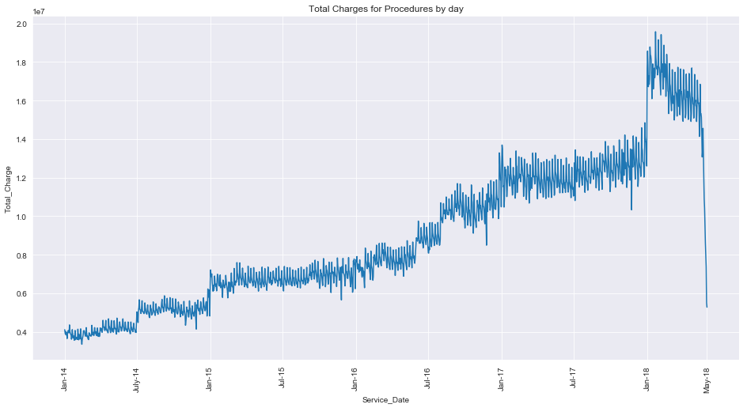

```python
line_plot('Service_Date','Total_Charge', df_service_date_metrics,'Total Charges for Procedures by day',['2014-01-01','2014-07-01','2015-01-01','2015-07-01','2016-01-01','2016-07-01','2017-01-01','2017-07-01','2018-01-01','2018-05-31'], ['Jan-14','July-14','Jan-15','Jul-15','Jan-16','Jul-16','Jan-17','Jul-17','Jan-18','May-18'],"")
print(df_service_date_metrics.Total_Charge.mean())
```

```
13812.678039702234
```

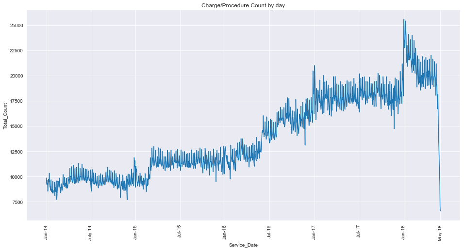

```python
line_plot('Service_Date','Total_Count', df_service_date_metrics,'Charge/Procedure Count by day',['2014-01-01','2014-07-01','2015-01-01','2015-07-01','2016-01-01','2016-07-01','2017-01-01','2017-07-01','2018-01-01','2018-05-31'], ['Jan-14','July-14','Jan-15','Jul-15','Jan-16','Jul-16','Jan-17','Jul-17','Jan-18','May-18'],"")
print(df_service_date_metrics.Total_Count.mean())
```

### What are the different types of typical charges?

- There are 4 prominent charges (represented as bumps in the distribution)
- The 4 charges map to the most common procedures
- Charges are typically between \$0 and \$1,800

[figure not shown]

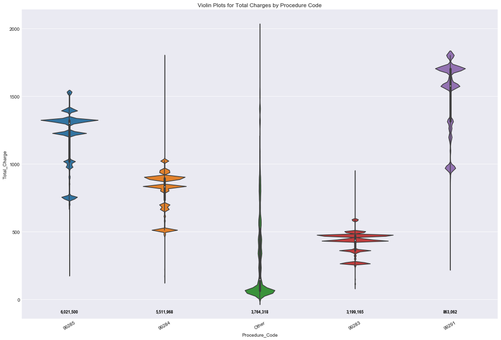

```python
#Plots for total charges by procedure code
violin_plot(df_pmt, 'Procedure_Code', 'Total_Charge', -700,2000,'Violin Plots for Total Charges by Procedure Code','desc',-100)
```

```
Procedure Count by Month
```

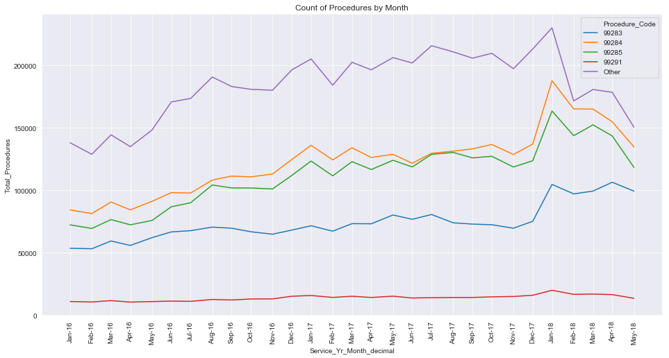

```python
line_plot('Service_Yr_Month_decimal','Total_Procedures', df_proc_status_by_month,'Count of Procedures by Month',sorted(list(set(df_proc_status_by_month['Service_Yr_Month_decimal']))), ['Jan-16','Feb-16','Mar-16','Apr-16','May-16','Jun-16','Jul-16','Aug-16','Sep-16','Oct-16','Nov-16','Dec-16','Jan-17','Feb-17','Mar-17','Apr-17','May-17','Jun-17','Jul-17','Aug-17','Sep-17','Oct-17','Nov-17','Dec-17','Jan-18','Feb-18','Mar-18','Apr-18','May-18'],"Procedure_Code")
print('Procedure Count by Month')
```

```
Procedure Count by Month
```

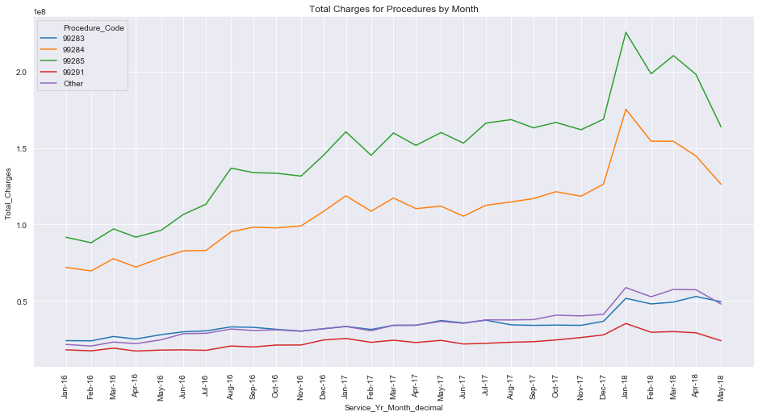

```python
line_plot('Service_Yr_Month_decimal','Total_Charges', df_proc_status_by_month,'Total Charges for Procedures by Month',sorted(list(set(df_proc_status_by_month['Service_Yr_Month_decimal']))), ['Jan-16','Feb-16','Mar-16','Apr-16','May-16','Jun-16','Jul-16','Aug-16','Sep-16','Oct-16','Nov-16','Dec-16','Jan-17','Feb-17','Mar-17','Apr-17','May-17','Jun-17','Jul-17','Aug-17','Sep-17','Oct-17','Nov-17','Dec-17','Jan-18','Feb-18','Mar-18','Apr-18','May-18'],"Procedure_Code")
print('Procedure Count by Month')
```

[figure not shown]

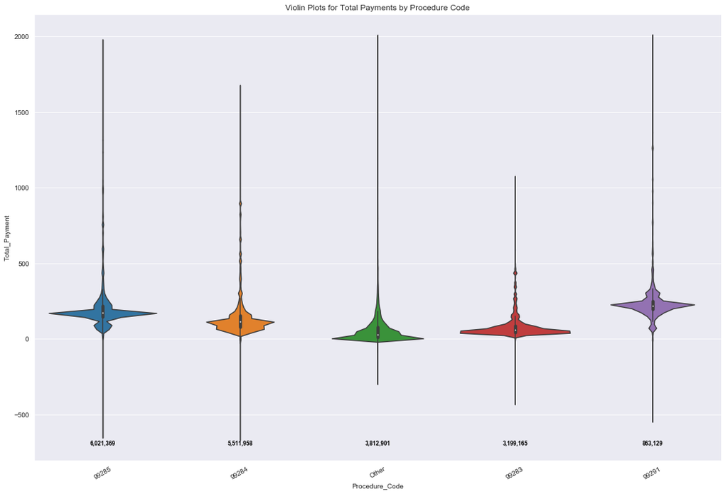

```python
violin_plot(df_pmt, 'Procedure_Code', 'Total_Payment', -700,2000,'Violin Plots for Total Payments by Procedure Code','desc',-700)
```

## How long does it typically take for payment and are there patterns in payments?

- The median number of days (weighted) till payment is 29 days
- Typically, the majority of payments are made between 2 and 8 weeks
- Nearly all claims are adjudicated within 1 year (2% of charges are unadjudicated from 1 year ago)
- Different procedures have slight variations on time-to-payment
- Payer groupings vary widely in percentage paid on charges (10% - 50%)
- Payments are typically between \$0 and \$300

```
Median:
```

```
29.0
```

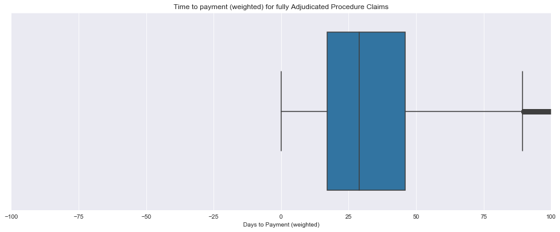

```python
#fully adjudicated claims are typically paid in 29 days.
fig = plt.figure(figsize=(16,6))
fig.add_subplot(1,1,1)
sns.set_style("darkgrid")
ax = sns.boxplot(x=df_wtd_pmt["Days to Payment (weighted)"])
ax.set(xlim=(-100, 100))
plt.title('Time to payment (weighted) for fully Adjudicated Procedure Claims')
print("Median:")
df_wtd_pmt["Days to Payment (weighted)"].median()
```

```
Weighted time to payment
```

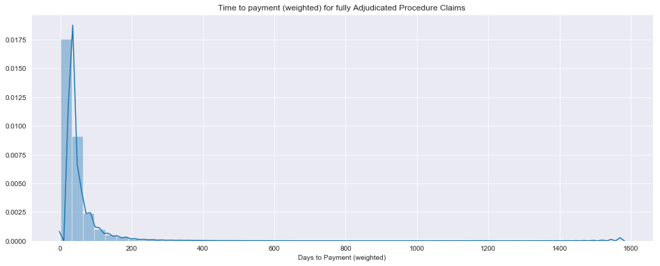

```python
fig = plt.figure(figsize=(16,6))
fig.add_subplot(1,1,1)
sns.set_style("darkgrid")
ax = sns.distplot(df_wtd_pmt["Days to Payment (weighted)"])
plt.title('Time to payment (weighted) for fully Adjudicated Procedure Claims')
print('Weighted time to payment')
```

```
Total Charges by month for Fully adjudicated vs. non-fully adjudicated
```

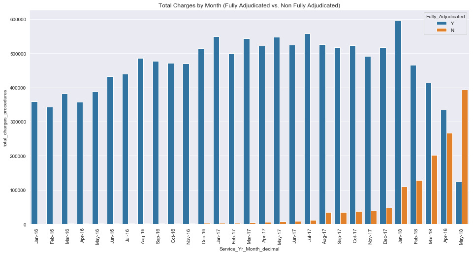

```python
bar_plot('Service_Yr_Month_decimal','total_charges_procedures', df_fa_status_by_month,'Total Charges by Month (Fully Adjudicated vs. Non Fully Adjudicated)',sorted(list(set(df_fa_status_by_month['Service_Yr_Month_decimal']))), ['Jan-16','Feb-16','Mar-16','Apr-16','May-16','Jun-16','Jul-16','Aug-16','Sep-16','Oct-16','Nov-16','Dec-16','Jan-17','Feb-17','Mar-17','Apr-17','May-17','Jun-17','Jul-17','Aug-17','Sep-17','Oct-17','Nov-17','Dec-17','Jan-18','Feb-18','Mar-18','Apr-18','May-18'],"Fully_Adjudicated",True)
print('Total Charges by month for Fully adjudicated vs. non-fully adjudicated')
```

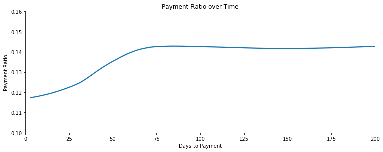

```python
#Payment ratio over time
pmt_plot(df_pmt, 'Days_to_payment', 'Cumulative_Payment_Ratio_Charge', '', True, 0, 200, .10, .16, 'Payment Ratio over Time', 'Days to Payment', 'Payment Ratio',12,4)
```

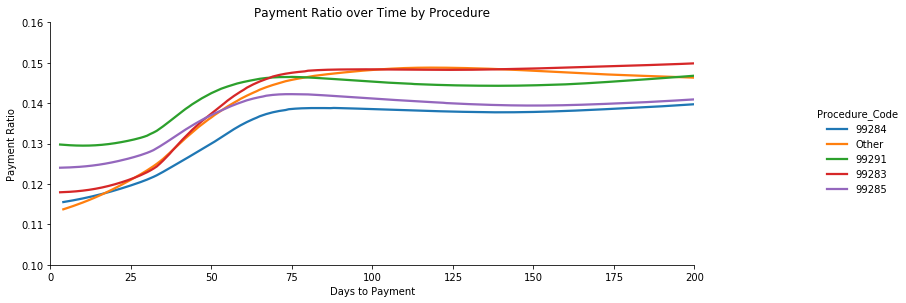

```python
#Payment ratio over time by procedure code
pmt_plot(df_pmt, 'Days_to_payment', 'Cumulative_Payment_Ratio_Charge', 'Procedure_Code', True, 0, 200, .10, .16, 'Payment Ratio over Time by Procedure', 'Days to Payment', 'Payment Ratio',14,4)
```

[figure not shown]

## Bringing it all together: Kernel Densiity estimation for charges and payments by Payer Grouping and top 5 procedures

- While Payer grouping and procedure help to explain payment rates and charge amounts, charges and payments still have different patterns/distributions.

Later, to estimate payments more precisely, we will attempt to bring in additional features to improve this estimate. Features will include: Service date, Site of procedure, location, and additional payer data.

```
Text(0.5,1,'Charges and Payments Kernel Density Estimation')
```

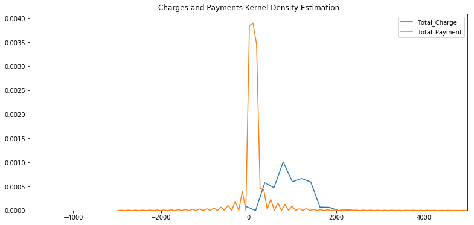

```python
plt.figure(figsize=(13, 6))
plt.subplot(1, 1, 1)
sns.kdeplot(df_pmt['Total_Charge'], legend=True)
sns.kdeplot(df_pmt['Total_Payment'], legend=True)
plt.xlim(-5000,5000)
plt.title('Charges and Payments Kernel Density Estimation')
```

[figure not shown]

# Test the Current Methodology

To test the methodology, the following steps were performed:

1. Choose a point in time where most of the charges are now fully adjudicated (so we can test a prediction from that point in time). Reviewing the above adjudicated vs. unadjudicated bar plot, we selected Jan 31st, 2017 where 99% of total charges are now fully adjudicated.
2. Use data for fully adjudicated charges prior to Jan 31st, 2017 to calculate the "GSR" ratio to apply (training set)
3. Apply the ratio to the set of charges as of Jan 31st 2017 that were not fully adjudicated at that time (test set).
4. Evaluate performance on 2 metrics:
   - Overall net difference: (Actual - Predicted)/Actual (excluding known payments made)
   - Net difference as a percentage for different sample sizes

## The "GSR" Model's overall prediction of payments is off by 11.5%

By applying the caclulated ratio of the average for group, site, and region, the predicted amount is off overall by 11.5%, and stabilizes around this amount once you look at a sample size greater than 100.

[figure not shown]

# Develop and Test a new model using a training sample

Developing and testing a new model includes the following steps:

1. Use all columns in a lasso regression model to predicts payments. Due to the large number of columns, we will use a sample of 350,000 rows for training. Further, a lasso regression will be useful for potential feature selection, by zero-ing out coefficients with negligible impact to the model.
2. Use all columns in a random forest model to predicts payments. Due to the large number of columns, we will use a sample of 350,000 rows for training. Similarly, we will investigate feature importances to assist with feature selection.

## Lasso Regression produces similar results to the "GSR" model

[figure not shown]

## Random Forest Model narrows the difference to 2%

[figure not shown]

# Evaluate Features and Select a final model

Based on the above 2 models we will investigate key features by doing the following:

1. Investigate the most influential features based on the Lasso regression coefficients and random forest feature importances
2. Select a subset of features to re-run the random forest model, as well as a multi-layered perceptron, and an ensemble bagging regressor.
3. Select the model that produces the least difference on the entire test set.
4. Follow the same process using the final model and features for the next 2 subsequent months (where the vast majority of charges are fully adjudicated) and confirm the results are similar.

## The Feature set may be reduced to 6 key features based on the results from the random forest and lasso regression models

The six key features we will use to create a model using all of the training data are:

- Service Year/Month
- Grouping
- Procedure Code
- Total charge
- Site Volume
- Region

[figure not shown]

# Re-running the multi-layer perceptron using the reduced "key" feature set

Multi-layer Perceptron (MLP) is a supervised learning algorithm that learns a function by training on a dataset, where m is the number of dimensions for input and o is the number of dimensions for output. Given a set of features X = {x_1, x_2, ..., x_m} and a target y, it can learn a non-linear function approximator for regression. It is different from logistic regression, in that between the input and the output layer, there can be one or more non-linear layers, called hidden layers. (Difference of 2.92%)

# Re-running the random forest using the reduced "key" feature set

Random Forest: A random forest is a meta estimator that fits a number of classifying decision trees on various sub-samples of the dataset and use averaging to improve the predictive accuracy and control over-fitting. The sub-sample size is always the same as the original input sample size but the samples are drawn with replacement if bootstrap=True (default). (Difference of .80%)